# Lab 1

# Open Response

For this exercise, use the **diamonds** dataset in the tidyverse. Use `?diamonds` to get more information about the dataset.

## Step 1: Select 1 numeric variable and 2 categorical variables. Create a graphic using `geom_boxplot()` and `facet_wrap` to illustrate the empirical distributions of the sample.

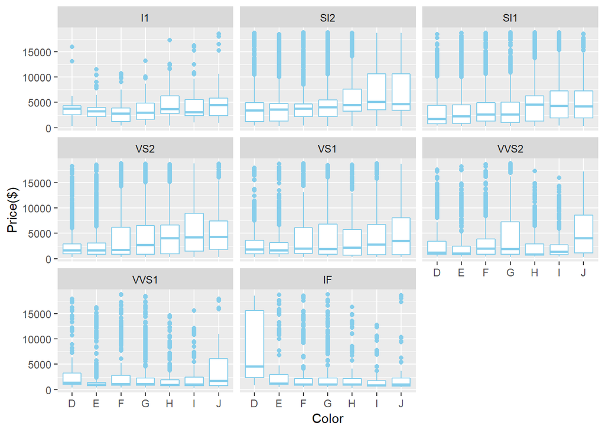

```r
ggplot(data=diamonds) +geom_boxplot(mapping =aes(x=color,y=price), color="sky blue") + facet_wrap(~clarity) +xlab("Color")+ylab("Price($)")
```

## Step 2: Choose 2 numeric variables and 2 categorical variables and creatively illustrate the relationship between all the variables.

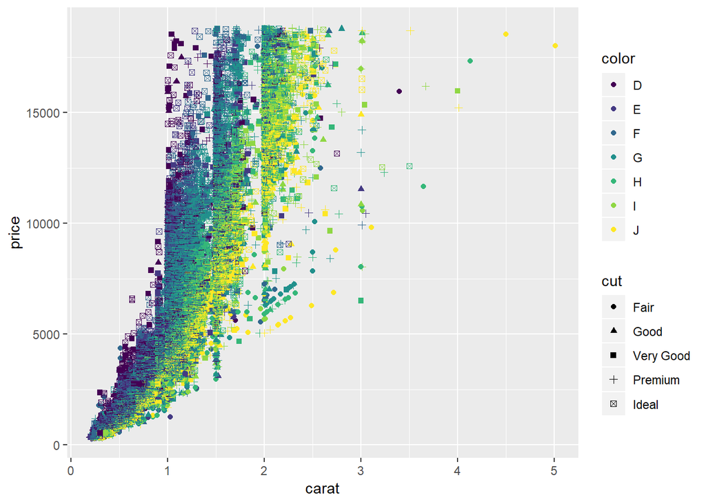

```r
ggplot(data=diamonds) +geom_point(aes(x = carat, y = price,color=color,shape=cut))
```